# State-Space models in mvgam

Nicholas J Clark

2026-01-19

The purpose of this vignette is to show how the `mvgam` package can be used to fit and interrogate State-Space models with nonlinear effects.

## State-Space Models

[figure not shown]

Illustration of a basic State-Space model, which assumes that a latent dynamic *process* (X) can evolve independently from the way we take *observations* (Y) of that process

State-Space models allow us to separately make inferences about the underlying dynamic *process model* that we are interested in (i.e. the evolution of a time series or a collection of time series) and the *observation model* (i.e. the way that we survey / measure this underlying process). This is extremely useful in ecology because our observations are always imperfect / noisy measurements of the thing we are interested in measuring. It is also helpful because we often know that some covariates will impact our ability to measure accurately (i.e. we cannot take accurate counts of rodents if there is a thunderstorm happening) while other covariates might impact the underlying process (it is highly unlikely that rodent abundance responds to one storm, but instead probably responds to longer-term weather and climate variation). A State-Space model allows us to model both components in a single unified modelling framework. A major advantage of `mvgam` is that it can include nonlinear effects and random effects in BOTH model components while also capturing dynamic processes.

### Lake Washington plankton data

The data we will use to illustrate how we can fit State-Space models in `mvgam` are from a long-term monitoring study of plankton counts (cells per mL) taken from Lake Washington in Washington, USA. The data are available as part of the `MARSS` package and can be downloaded using the following:

```r
load(url("https://github.com/atsa-es/MARSS/raw/master/data/lakeWAplankton.rda"))
```

We will work with five different groups of plankton:

```r
outcomes <- c("Greens", "Bluegreens", "Diatoms", "Unicells", "Other.algae")
```

As usual, preparing the data into the correct format for `mvgam` modelling takes a little bit of wrangling in `dplyr`:

```r
# loop across each plankton group to create the long datframe
plankton_data <- do.call(rbind, lapply(outcomes, function(x) {
  # create a group-specific dataframe with counts labelled 'y'
  # and the group name in the 'series' variable
  data.frame(
    year = lakeWAplanktonTrans[, "Year"],
    month = lakeWAplanktonTrans[, "Month"],
    y = lakeWAplanktonTrans[, x],
    series = x,
    temp = lakeWAplanktonTrans[, "Temp"]
  )
})) %>%
  # change the 'series' label to a factor
  dplyr::mutate(series = factor(series)) %>%
  # filter to only include some years in the data
  dplyr::filter(year >= 1965 & year < 1975) %>%
  dplyr::arrange(year, month) %>%
  dplyr::group_by(series) %>%
  # z-score the counts so they are approximately standard normal
  dplyr::mutate(y = as.vector(scale(y))) %>%
  # add the time indicator
  dplyr::mutate(time = dplyr::row_number()) %>%
  dplyr::ungroup()
```

Inspect the data structure

```r
head(plankton_data)
```

```
#> # A tibble: 6 × 6
#>    year month       y series       temp  time
#>   <dbl> <dbl>   <dbl> <fct>       <dbl> <int>
#> 1  1965     1 -0.542  Greens      -1.23     1
#> 2  1965     1 -0.344  Bluegreens  -1.23     1
#> 3  1965     1 -0.0768 Diatoms     -1.23     1
#> 4  1965     1 -1.52   Unicells    -1.23     1
#> 5  1965     1 -0.491  Other.algae -1.23     1
#> 6  1965     2 NA      Greens      -1.32     2
```

```r
dplyr::glimpse(plankton_data)
```

```
#> Rows: 600
#> Columns: 6
#> $ year   <dbl> 1965, 1965, 1965, 1965, 1965, 1965, 1965, 1965, 1965, 1965, 196…
#> $ month  <dbl> 1, 1, 1, 1, 1, 2, 2, 2, 2, 2, 3, 3, 3, 3, 3, 4, 4, 4, 4, 4, 5, …
#> $ y      <dbl> -0.54241769, -0.34410776, -0.07684901, -1.52243490, -0.49055442…
#> $ series <fct> Greens, Bluegreens, Diatoms, Unicells, Other.algae, Greens, Blu…
#> $ temp   <dbl> -1.2306562, -1.2306562, -1.2306562, -1.2306562, -1.2306562, -1.…
#> $ time   <int> 1, 1, 1, 1, 1, 2, 2, 2, 2, 2, 3, 3, 3, 3, 3, 4, 4, 4, 4, 4, 5, …
```

Note that we have z-scored the counts in this example as that will make it easier to specify priors (though this is not completely necessary; it is often better to build a model that respects the properties of the actual outcome variables)

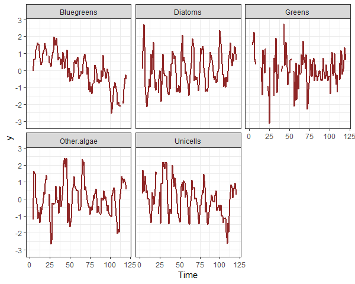

```r
plot_mvgam_series(data = plankton_data, series = "all")
```

We have some missing observations, but this isn’t an issue for modelling in `mvgam`. A useful property to understand about these counts is that they tend to be highly seasonal. Below are some plots of z-scored counts against the z-scored temperature measurements in the lake for each month:

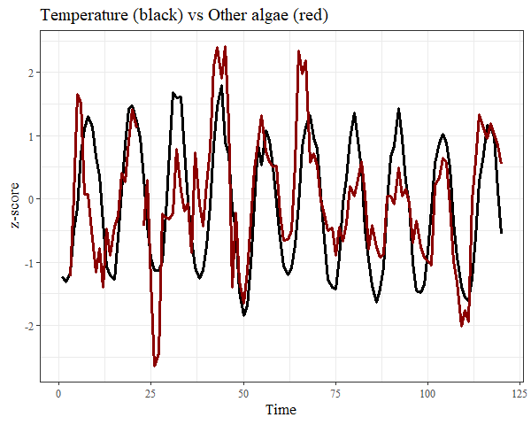

```r
plankton_data %>%
  dplyr::filter(series == "Other.algae") %>%
  ggplot(aes(x = time, y = temp)) +
  geom_line(size = 1.1) +
  geom_line(aes(y = y),
    col = "white",
    size = 1.3
  ) +
  geom_line(aes(y = y),
    col = "darkred",
    size = 1.1
  ) +
  ylab("z-score") +
  xlab("Time") +
  ggtitle("Temperature (black) vs Other algae (red)")
```

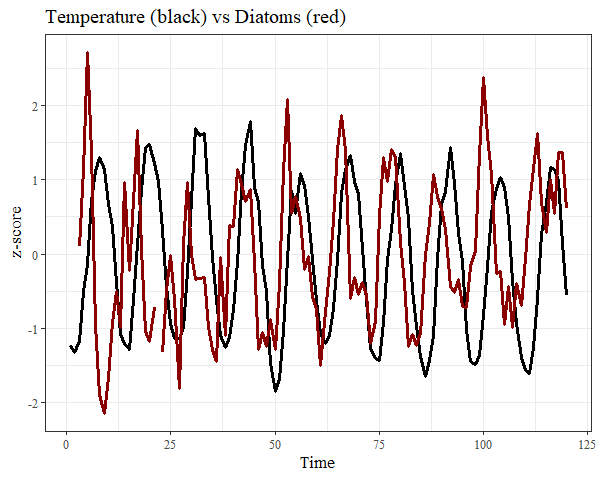

```r
plankton_data %>%
  dplyr::filter(series == "Diatoms") %>%
  ggplot(aes(x = time, y = temp)) +
  geom_line(size = 1.1) +
  geom_line(aes(y = y),
    col = "white",
    size = 1.3
  ) +
  geom_line(aes(y = y),
    col = "darkred",
    size = 1.1
  ) +
  ylab("z-score") +
  xlab("Time") +
  ggtitle("Temperature (black) vs Diatoms (red)")
```

We will have to try and capture this seasonality in our process model, which should be easy to do given the flexibility of GAMs. Next we will split the data into training and testing splits:

```r
plankton_train <- plankton_data %>%
  dplyr::filter(time <= 112)
plankton_test <- plankton_data %>%
  dplyr::filter(time > 112)
```

Now time to fit some models. This requires a bit of thinking about how we can best tackle the seasonal variation and the likely dependence structure in the data. These algae are interacting as part of a complex system within the same lake, so we certainly expect there to be some lagged cross-dependencies underling their dynamics. But if we do not capture the seasonal variation, our multivariate dynamic model will be forced to try and capture it, which could lead to poor convergence and unstable results (we could feasibly capture cyclic dynamics with a more complex multi-species Lotka-Volterra model, but ordinary differential equation approaches are beyond the scope of `mvgam`).

### Capturing seasonality

First we will fit a model that does not include a dynamic component, just to see if it can reproduce the seasonal variation in the observations. This model introduces hierarchical multidimensional smooths, where all time series share a “global” tensor product of the `month` and `temp` variables, capturing our expectation that algal seasonality responds to temperature variation. But this response should depend on when in the year these temperatures are recorded (i.e. a response to warm temperatures in Spring should be different to a response to warm temperatures in Autumn). The model also fits series-specific deviation smooths (i.e. one tensor product per series) to capture how each algal group’s seasonality differs from the overall “global” seasonality. Note that we do not include series-specific intercepts in this model because each series was z-scored to have a mean of 0.

```r
notrend_mod <- mvgam(
  y ~
    # tensor of temp and month to capture
    # "global" seasonality
    te(temp, month, k = c(4, 4)) +

    # series-specific deviation tensor products
    te(temp, month, k = c(4, 4), by = series) - 1,
  family = gaussian(),
  data = plankton_train,
  newdata = plankton_test,
  trend_model = "None"
)
```

The “global” tensor product smooth function can be quickly visualized:

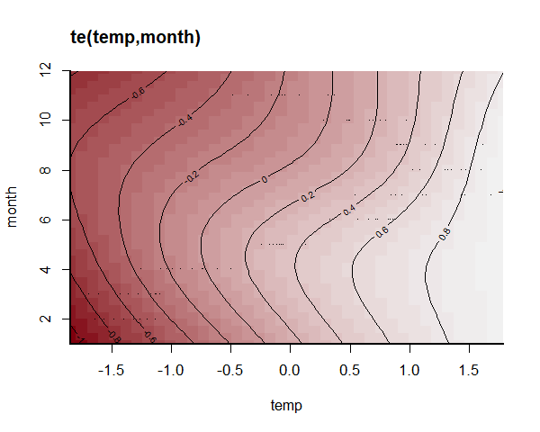

```r
plot_mvgam_smooth(notrend_mod, smooth = 1)
```

On this plot, red indicates below-average linear predictors and white indicates above-average. We can then plot the deviation smooths for a few algal groups to see how they vary from the “global” pattern:

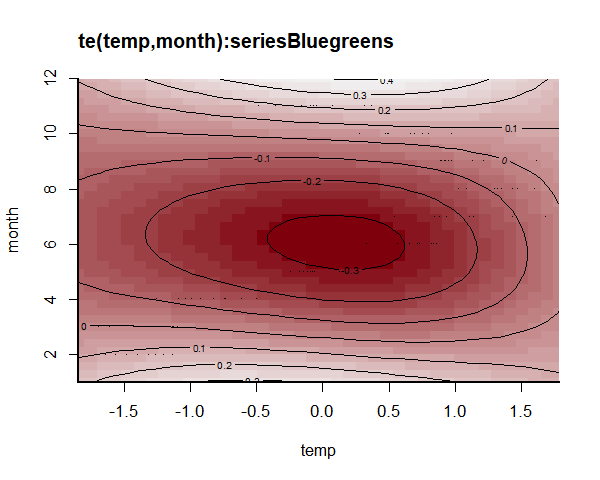

```r
plot_mvgam_smooth(notrend_mod, smooth = 2)
```

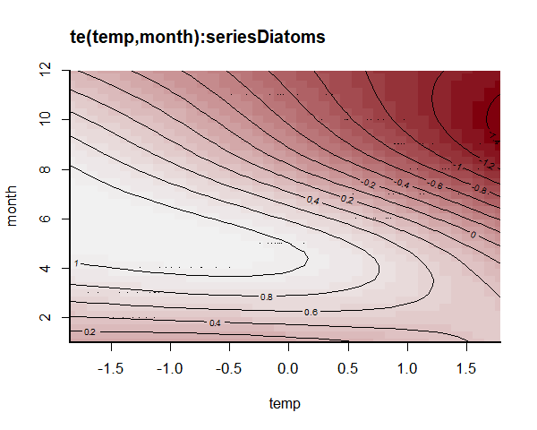

```r
plot_mvgam_smooth(notrend_mod, smooth = 3)
```

These multidimensional smooths have done a good job of capturing the seasonal variation in our observations:

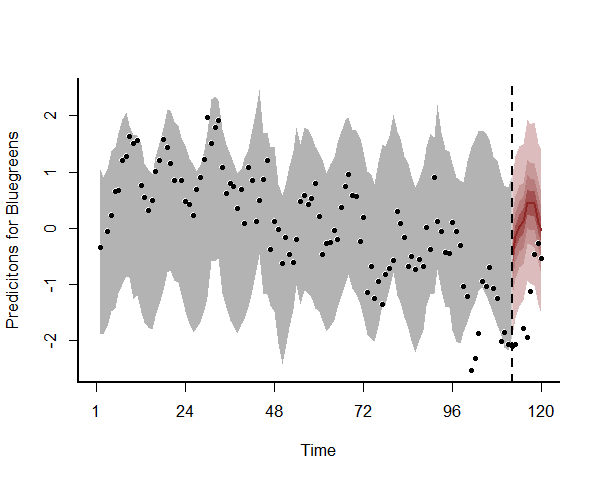

```r
plot(notrend_mod, type = "forecast", series = 1)
```

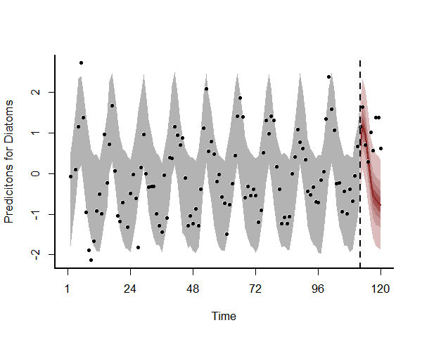

```r
plot(notrend_mod, type = "forecast", series = 2)
```

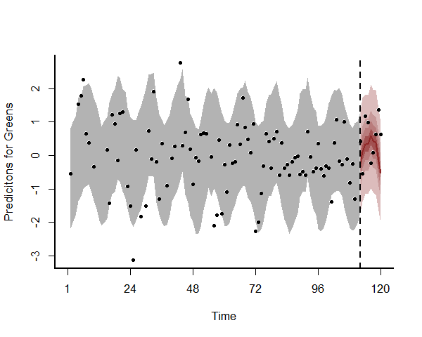

```r
plot(notrend_mod, type = "forecast", series = 3)
```

This basic model gives us confidence that we can capture the seasonal variation in the observations. But the model has not captured the remaining temporal dynamics, which is obvious when we inspect Dunn-Smyth residuals for a few series:

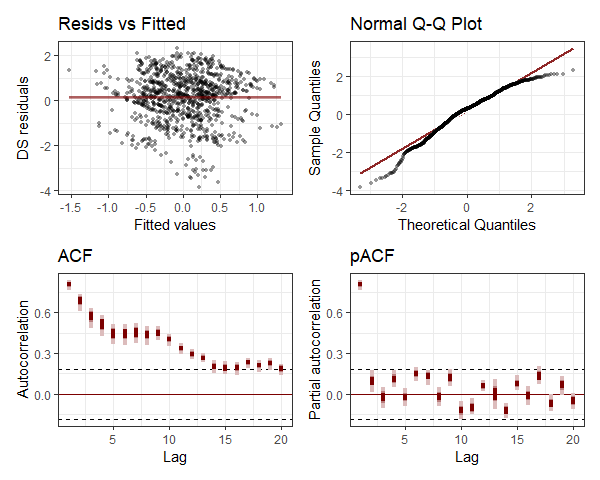

```r
plot(notrend_mod, type = "residuals", series = 1)
```

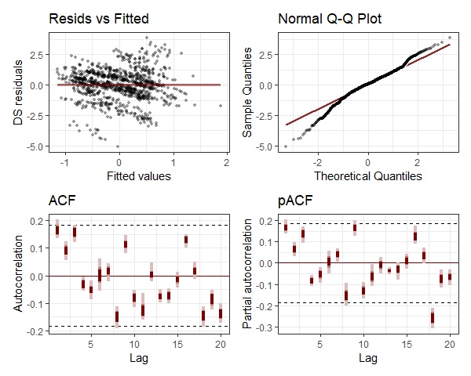

```r
plot(notrend_mod, type = "residuals", series = 3)
```

### Multiseries dynamics

Now it is time to get into multivariate State-Space models. We will fit two models that can both incorporate lagged cross-dependencies in the latent process models. The first model assumes that the process errors operate independently from one another, while the second assumes that there may be contemporaneous correlations in the process errors. Both models include a Vector Autoregressive component for the process means, and so both can model complex community dynamics. The models can be described mathematically as follows:

$$\begin{align*}
\boldsymbol{count}_t & \sim \text{Normal}(\mu_{obs[t]},
\sigma_{obs}) \\
\mu_{obs[t]} & = process_t \\
process_t & \sim \text{MVNormal}(\mu_{process[t]}, \Sigma_{process})
\\
\mu_{process[t]} & = A * process_{t-1} +
f_{global}(\boldsymbol{month},\boldsymbol{temp})_t +
f_{series}(\boldsymbol{month},\boldsymbol{temp})_t \\
f_{global}(\boldsymbol{month},\boldsymbol{temp}) & =
\sum_{k=1}^{K}b_{global} * \beta_{global} \\
f_{series}(\boldsymbol{month},\boldsymbol{temp}) & =
\sum_{k=1}^{K}b_{series} * \beta_{series} \end{align*}$$

Here you can see that there are no terms in the observation model apart from the underlying process model. But we could easily add covariates into the observation model if we felt that they could explain some of the systematic observation errors. We also assume independent observation processes (there is no covariance structure in the observation errors $\sigma_{obs}$). At present, `mvgam` does not support multivariate observation models. But this feature will be added in future versions. However the underlying process model is multivariate, and there is a lot going on here. This component has a Vector Autoregressive part, where the process mean at time $t$ $(\mu_{process[t]})$ is a vector that evolves as a function of where the vector-valued process model was at time $t-1$. The $A$ matrix captures these dynamics with self-dependencies on the diagonal and possibly asymmetric cross-dependencies on the off-diagonals, while also incorporating the nonlinear smooth functions that capture seasonality for each series. The contemporaneous process errors are modeled by $\Sigma_{process}$, which can be constrained so that process errors are independent (i.e. setting the off-diagonals to 0) or can be fully parameterized using a Cholesky decomposition (using `Stan`’s $LKJcorr$ distribution to place a prior on the strength of inter-species correlations). For those that are interested in the inner-workings, `mvgam` makes use of a recent breakthrough by [Sarah Heaps to enforce stationarity of Bayesian VAR processes](https://www.tandfonline.com/doi/full/10.1080/10618600.2022.2079648). This is advantageous as we often don’t expect forecast variance to increase without bound forever into the future, but many estimated VARs tend to behave this way.

Ok that was a lot to take in. Let’s fit some models to try and inspect what is going on and what they assume. But first, we need to update `mvgam`’s default priors for the observation and process errors. By default, `mvgam` uses a fairly wide Student-T prior on these parameters to avoid being overly informative. But our observations are z-scored and so we do not expect very large process or observation errors. However, we also do not expect very small observation errors either as we know these measurements are not perfect. So let’s update the priors for these parameters. In doing so, you will get to see how the formula for the latent process (i.e. trend) model is used in `mvgam`:

```r
priors <- get_mvgam_priors(
  # observation formula, which has no terms in it
  y ~ -1,

  # process model formula, which includes the smooth functions
  trend_formula = ~ te(temp, month, k = c(4, 4)) +
    te(temp, month, k = c(4, 4), by = trend) - 1,

  # VAR1 model with uncorrelated process errors
  trend_model = VAR(),
  family = gaussian(),
  data = plankton_train
)
```

Get names of all parameters whose priors can be modified:

```r
priors[, 3]
```

```
#>  [1] "(Intercept)"
#>  [2] "process error sd"
#>  [3] "diagonal autocorrelation population mean"
#>  [4] "off-diagonal autocorrelation population mean"
#>  [5] "diagonal autocorrelation population variance"
#>  [6] "off-diagonal autocorrelation population variance"
#>  [7] "shape1 for diagonal autocorrelation precision"
#>  [8] "shape1 for off-diagonal autocorrelation precision"
#>  [9] "shape2 for diagonal autocorrelation precision"
#> [10] "shape2 for off-diagonal autocorrelation precision"
#> [11] "observation error sd"
#> [12] "te(temp,month) smooth parameters, te(temp,month):trendtrend1 smooth parameters, te(temp,month):trendtrend2 smooth parameters, te(temp,month):trendtrend3 smooth parameters, te(temp,month):trendtrend4 smooth parameters, te(temp,month):trendtrend5 smooth parameters"
```

And their default prior distributions:

```r
priors[, 4]
```

```
#>  [1] "(Intercept) ~ student_t(3, -0.1, 2.5);"
#>  [2] "sigma ~ inv_gamma(1.418, 0.452);"
#>  [3] "es[1] = 0;"
#>  [4] "es[2] = 0;"
#>  [5] "fs[1] = sqrt(0.455);"
#>  [6] "fs[2] = sqrt(0.455);"
#>  [7] "gs[1] = 1.365;"
#>  [8] "gs[2] = 1.365;"
#>  [9] "hs[1] = 0.071175;"
#> [10] "hs[2] = 0.071175;"
#> [11] "sigma_obs ~ inv_gamma(1.418, 0.452);"
#> [12] "lambda_trend ~ normal(5, 30);"
```

Setting priors is easy in `mvgam` as you can use `brms` routines. Here we use more informative Normal priors for both error components, but we impose a lower bound of 0.2 for the observation errors:

```r
priors <- c(
  prior(normal(0.5, 0.1), class = sigma_obs, lb = 0.2),
  prior(normal(0.5, 0.25), class = sigma)
)
```

You may have noticed something else unique about this model: there is no intercept term in the observation formula. This is because a shared intercept parameter can sometimes be unidentifiable with respect to the latent VAR process, particularly if our series have similar long-run averages (which they do in this case because they were z-scored). We will often get better convergence in these State-Space models if we drop this parameter. `mvgam` accomplishes this by fixing the coefficient for the intercept to zero. Now we can fit the first model, which assumes that process errors are contemporaneously uncorrelated

```r
var_mod <- mvgam(
  # observation formula, which is empty
  forumla = y ~ -1,

  # process model formula, which includes the smooth functions
  trend_formula = ~ te(temp, month, k = c(4, 4)) +
    te(temp, month, k = c(4, 4), by = trend) - 1,

  # VAR1 model with uncorrelated process errors
  trend_model = VAR(),
  family = gaussian(),
  data = plankton_train,
  newdata = plankton_test,

  # include the updated priors
  priors = priors,
  silent = 2
)
```

### Inspecting SS models

```r
summary(var_mod, include_betas = FALSE)
```

```
#> GAM observation formula:
#> y ~ 1
#> <environment: 0x0000019b25b15728>
#>
#> GAM process formula:
#> ~te(temp, month, k = c(4, 4)) + te(temp, month, k = c(4, 4),
#>     by = trend) - 1
#> <environment: 0x0000019b25b15728>
#>
#> Family:
#> gaussian
#>
#> Link function:
#> identity
#>
#> Trend model:
#> VAR()
#>
#> N process models:
#> 5
#>
#> N series:
#> 5
#>
#> N timepoints:
#> 120
#>
#> Status:
#> Fitted using Stan
#> 4 chains, each with iter = 1500; warmup = 1000; thin = 1
#> Total post-warmup draws = 2000
#>
#> Observation error parameter estimates:
#>              2.5%  50% 97.5% Rhat n_eff
#> sigma_obs[1] 0.20 0.26  0.34 1.01   302
#> sigma_obs[2] 0.24 0.40  0.54 1.02   150
#> sigma_obs[3] 0.43 0.63  0.80 1.04   100
#> sigma_obs[4] 0.25 0.37  0.49 1.01   301
#> sigma_obs[5] 0.31 0.43  0.54 1.03   190
#>
```

[output cut: 45 more lines]

```
#> te(temp,month):seriestrend3 1.708     15  2.274   1.000
#> te(temp,month):seriestrend4 1.345     15  5.607   1.000
#> te(temp,month):seriestrend5 2.565     15  7.698   0.965
#>
#> Stan MCMC diagnostics:
#> ✔ No issues with effective samples per iteration
#> ✔ Rhat looks good for all parameters
#> ✔ No issues with divergences
#> ✔ No issues with maximum tree depth
#>
#> Samples were drawn using sampling(hmc). For each parameter, n_eff is a
#>   crude measure of effective sample size, and Rhat is the potential scale
#>   reduction factor on split MCMC chains (at convergence, Rhat = 1)
#>
#> Use how_to_cite() to get started describing this model
```

The convergence of this model isn’t fabulous (more on this in a moment). But we can again plot the smooth functions, which this time operate on the process model. We can see the same plot using `trend_effects = TRUE` in the plotting functions:

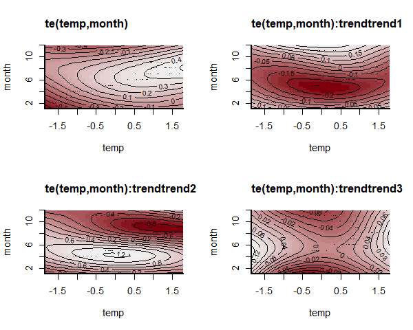

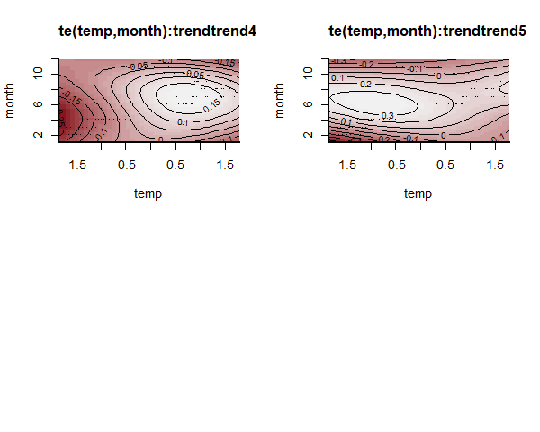

```r
plot(var_mod, "smooths", trend_effects = TRUE)
```

The autoregressive coefficient matrix is of particular interest here, as it captures lagged dependencies and cross-dependencies in the latent process model. Unfortunately `bayesplot` doesn’t know this is a matrix of parameters so what we see is actually the transpose of the VAR matrix. Using `dir = 'v'` in the `facet_args` argument will accomplish this:

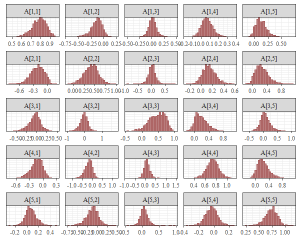

```r
mcmc_plot(
  var_mod,
  variable = 'A',
  regex = TRUE,
  type = 'hist',
  facet_args = list(dir = 'v')
)
```

There is a lot happening in this matrix. Each cell captures the lagged effect of the process in the column on the process in the row in the next timestep. So for example, the effect in cell [1,3] shows how an *increase* in the process for series 3 (Greens) at time $t$ is expected to impact the process for series 1 (Bluegreens) at time $t+1$. The latent process model is now capturing these effects and the smooth seasonal effects.

The process error $(\Sigma)$ captures unmodelled variation in the process models. Again, we fixed the off-diagonals to 0, so the histograms for these will look like flat boxes:

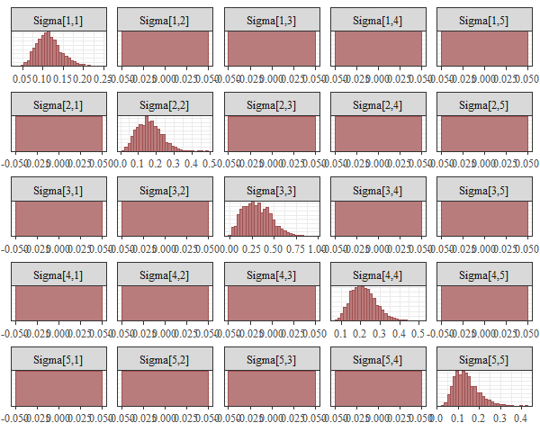

```r
mcmc_plot(
  var_mod,
  variable = 'Sigma',
  regex = TRUE,
  type = 'hist',
  facet_args = list(dir = 'v')
)
```

The observation error estimates $(\sigma_{obs})$ represent how much the model thinks we might miss the true count when we take our imperfect measurements:

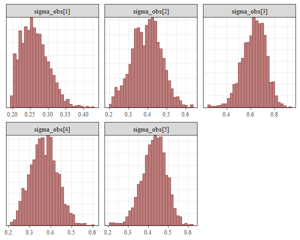

```r
mcmc_plot(var_mod, variable = "sigma_obs", regex = TRUE, type = "hist")
```

These are still a bit hard to identify overall, especially when trying to estimate both process and observation error. Often we need to make some strong assumptions about which of these is more important for determining unexplained variation in our observations.

### Correlated process errors

Let’s see if these estimates improve when we allow the process errors to be correlated. Once again, we need to first update the priors for the observation errors:

```r
priors <- c(
  prior(normal(0.5, 0.1), class = sigma_obs, lb = 0.2),
  prior(normal(0.5, 0.25), class = sigma)
)
```

And now we can fit the correlated process error model

```r
varcor_mod <- mvgam(
  # observation formula, which remains empty
  formula = y ~ -1,

  # process model formula, which includes the smooth functions
  trend_formula = ~ te(temp, month, k = c(4, 4)) +
    te(temp, month, k = c(4, 4), by = trend) - 1,

  # VAR1 model with correlated process errors
  trend_model = VAR(cor = TRUE),
  family = gaussian(),
  data = plankton_train,
  newdata = plankton_test,

  # include the updated priors
  priors = priors,
  silent = 2
)
```

The $(\Sigma)$ matrix now captures any evidence of contemporaneously correlated process error:

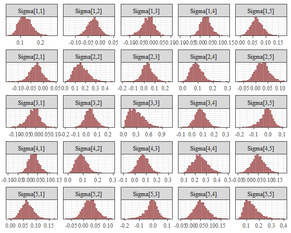

```r
mcmc_plot(
  varcor_mod,
  variable = 'Sigma',
  regex = TRUE,
  type = 'hist',
  facet_args = list(dir = 'v')
)
```

This symmetric matrix tells us there is support for correlated process errors, as several of the off-diagonal entries are strongly non-zero. But it is easier to interpret these estimates if we convert the covariance matrix to a correlation matrix. Here we compute the posterior median process error correlations:

```r
Sigma_post <- as.matrix(
  varcor_mod,
  variable = "Sigma",
  regex = TRUE
)
median_correlations <- cov2cor(
  matrix(apply(Sigma_post, 2, median),
         nrow = 5,
         ncol = 5
  )
)
rownames(median_correlations) <-
  colnames(median_correlations) <-
  levels(plankton_train$series)

round(median_correlations, 2)
```

```
#>             Bluegreens Diatoms Greens Other.algae Unicells
#> Bluegreens        1.00   -0.21  -0.05        0.17     0.51
#> Diatoms          -0.21    1.00   0.15        0.46     0.18
#> Greens           -0.05    0.15   1.00        0.29    -0.06
#> Other.algae       0.17    0.46   0.29        1.00     0.28
#> Unicells          0.51    0.18  -0.06        0.28     1.00
```

### Impulse response functions

Because Vector Autoregressions can capture complex lagged dependencies, it is often difficult to understand how the member time series are thought to interact with one another. A method that is commonly used to directly test for possible interactions is to compute an [Impulse Response Function](https://en.wikipedia.org/wiki/Impulse_response) (IRF). If $h$ represents the simulated forecast horizon, an IRF asks how each of the remaining series might respond over times $(t+1):h$ if a focal series is given an innovation “shock” at time $t = 0$. `mvgam` can compute Generalized and Orthogonalized IRFs from models that included latent VAR dynamics. We simply feed the fitted model to the `irf()` function and then use the S3 `plot()` function to view the estimated responses. By default, `irf()` will compute IRFs by separately imposing positive shocks of one standard deviation to each series in the VAR process. Here we compute Generalized IRFs over a horizon of 12 timesteps:

```r
irfs <- irf(varcor_mod, h = 12)
```

A summary of the IRFs can be computed using the `summary()` function:

```r
summary(irfs)
```

```
#> # A tibble: 300 × 5
#>    shock                  horizon irfQ50 irfQ2.5 irfQ97.5
#>    <chr>                    <int>  <dbl>   <dbl>    <dbl>
#>  1 Process_1 -> Process_1       1 0.349   0.269     0.442
#>  2 Process_1 -> Process_1       2 0.296   0.229     0.368
#>  3 Process_1 -> Process_1       3 0.251   0.191     0.321
#>  4 Process_1 -> Process_1       4 0.213   0.155     0.285
#>  5 Process_1 -> Process_1       5 0.182   0.123     0.253
#>  6 Process_1 -> Process_1       6 0.156   0.0956    0.226
#>  7 Process_1 -> Process_1       7 0.133   0.0732    0.204
#>  8 Process_1 -> Process_1       8 0.114   0.0549    0.185
#>  9 Process_1 -> Process_1       9 0.0981  0.0400    0.170
#> 10 Process_1 -> Process_1      10 0.0840  0.0300    0.156
#> # ℹ 290 more rows
```

But it is easier to understand these responses using plots. For example, we can plot the expected responses of the remaining series to a positive shock for series 3 (Greens) using the `plot()` function:

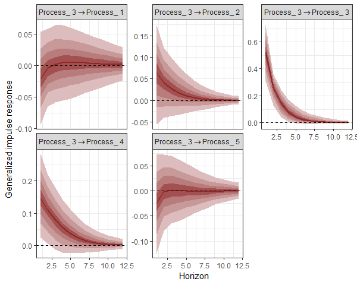

```r
plot(irfs, series = 3)
```

This series of plots makes it clear that some of the other series would be expected to show both instantaneous responses to a shock for the Greens (due to their correlated process errors) as well as delayed and nonlinear responses over time (due to the complex lagged dependence structure captured by the $A$ matrix). This hopefully makes it clear why IRFs are an important tool in the analysis of multivariate autoregressive models. You can also use these IRFs to calculate a relative contribution from each shock to the forecast error variance for a focal series. This method, known as a [Forecast Error Variance Decomposition](https://en.wikipedia.org/wiki/Variance_decomposition_of_forecast_errors) (FEVD), is useful to get an idea about the amount of information that each series contributes to the evolution of all other series in a Vector Autoregression:

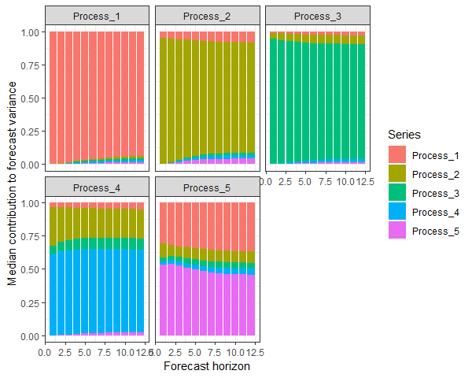

```r
fevds <- fevd(varcor_mod, h = 12)
plot(fevds)
```

The plot above shows the median contribution to forecast error variance for each series.

### Comparing forecast scores

But which model is better? We can compute the variogram score for out of sample forecasts to get a sense of which model does a better job of capturing the dependence structure in the true evaluation set:

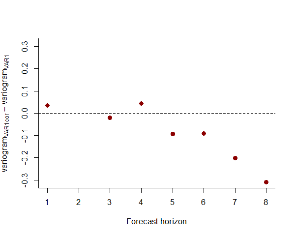

```r
# create forecast objects for each model
fcvar <- forecast(var_mod)
fcvarcor <- forecast(varcor_mod)

# plot the difference in variogram scores; a negative value means the VAR1cor model is better, while a positive value means the VAR1 model is better
diff_scores <- score(fcvarcor, score = "variogram")$all_series$score -
  score(fcvar, score = "variogram")$all_series$score
plot(diff_scores,
  pch = 16, cex = 1.25, col = "darkred",
  ylim = c(
    -1 * max(abs(diff_scores), na.rm = TRUE),
    max(abs(diff_scores), na.rm = TRUE)
  ),
  bty = "l",
  xlab = "Forecast horizon",
  ylab = expression(variogram[VAR1cor] ~ -~ variogram[VAR1])
)
abline(h = 0, lty = "dashed")
```

And we can also compute the energy score for out of sample forecasts to get a sense of which model provides forecasts that are better calibrated:

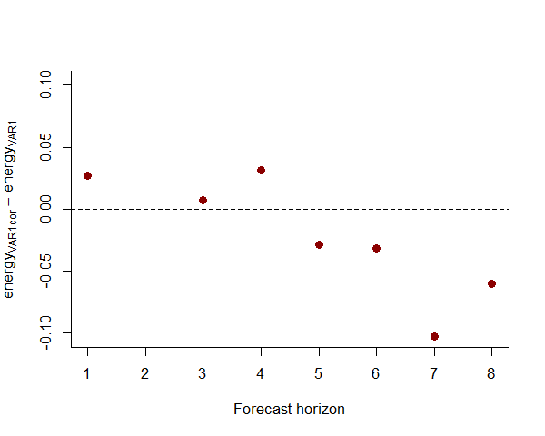

```r
# plot the difference in energy scores; a negative value means the VAR1cor model is better, while a positive value means the VAR1 model is better
diff_scores <- score(fcvarcor, score = "energy")$all_series$score -
  score(fcvar, score = "energy")$all_series$score
plot(diff_scores,
  pch = 16, cex = 1.25, col = "darkred",
  ylim = c(
    -1 * max(abs(diff_scores), na.rm = TRUE),
    max(abs(diff_scores), na.rm = TRUE)
  ),
  bty = "l",
  xlab = "Forecast horizon",
  ylab = expression(energy[VAR1cor] ~ -~ energy[VAR1])
)
abline(h = 0, lty = "dashed")
```

The models tend to provide similar forecasts, though the correlated error model does slightly better overall. We would probably need to use a more extensive rolling forecast evaluation exercise if we felt like we needed to only choose one for production. `mvgam` offers some utilities for doing this (i.e. see `?lfo_cv` for guidance). Alternatively, we could use forecasts from *both* models by creating an evenly-weighted ensemble forecast distribution. This capability is available using the `ensemble()` function in `mvgam` (see `?ensemble` for guidance).

Using `how_to_cite()` for models with VAR dynamics will give you information on how they are restricted to remain stationary:

```r
description <- how_to_cite(varcor_mod)
```

```r
description
```

```
#> Methods text skeleton
#> We used the R package mvgam (version 1.1.52; Clark & Wells, 2023) to
#>   construct, fit and interrogate the model. mvgam fits Bayesian
#>   State-Space models that can include flexible predictor effects in both
#>   the process and observation components by incorporating functionalities
#>   from the brms (Burkner 2017), mgcv (Wood 2017) and splines2 (Wang & Yan,
#>   2023) packages. To encourage stability and prevent forecast variance
#>   from increasing indefinitely, we enforced stationarity of the Vector
#>   Autoregressive process following methods described by Heaps (2023) and
#>   Clark et al. (2025). The mvgam-constructed model and observed data were
#>   passed to the probabilistic programming environment Stan (version
#>   2.36.0; Carpenter et al. 2017, Stan Development Team 2026), specifically
#>   through the cmdstanr interface (Gabry & Cesnovar, 2021). We ran 4
#>   Hamiltonian Monte Carlo chains for 1000 warmup iterations and 500
#>   sampling iterations for joint posterior estimation. Rank normalized
#>   split Rhat (Vehtari et al. 2021) and effective sample sizes were used to
#>   monitor convergence.
```

```
#>
#> Primary references
#> Clark, NJ and Wells K (2023). Dynamic Generalized Additive Models
#>   (DGAMs) for forecasting discrete ecological time series. Methods in
#>   Ecology and Evolution, 14, 771-784. doi.org/10.1111/2041-210X.13974
#> Burkner, PC (2017). brms: An R Package for Bayesian Multilevel Models
#>   Using Stan. Journal of Statistical Software, 80(1), 1-28.
#>   doi:10.18637/jss.v080.i01
#> Wood, SN (2017). Generalized Additive Models: An Introduction with R
#>   (2nd edition). Chapman and Hall/CRC.
#> Wang W and Yan J (2021). Shape-Restricted Regression Splines with R
#>   Package splines2. Journal of Data Science, 19(3), 498-517.
#>   doi:10.6339/21-JDS1020 https://doi.org/10.6339/21-JDS1020.
#> Heaps, SE (2023). Enforcing stationarity through the prior in vector
#>   autoregressions. Journal of Computational and Graphical Statistics 32,
#>   74-83.
#> Clark NJ, Ernest SKM, Senyondo H, Simonis J, White EP, Yenni GM,
#>   Karunarathna KANK (2025). Beyond single-species models: leveraging
#>   multispecies forecasts to navigate the dynamics of ecological
#>   predictability. PeerJ 13:e18929.
#> Carpenter B, Gelman A, Hoffman MD, Lee D, Goodrich B, Betancourt M,
#>   Brubaker M, Guo J, Li P and Riddell A (2017). Stan: A probabilistic
#>   programming language. Journal of Statistical Software 76.
#> Gabry J, Cesnovar R, Johnson A, and Bronder S (2026). cmdstanr: R
#>   Interface to 'CmdStan'. https://mc-stan.org/cmdstanr/,
#>   https://discourse.mc-stan.org.
#> Vehtari A, Gelman A, Simpson D, Carpenter B, and Burkner P (2021).
#>   Rank-normalization, folding, and localization: An improved Rhat for
#>   assessing convergence of MCMC (with discussion). Bayesian Analysis 16(2)
#>   667-718. https://doi.org/10.1214/20-BA1221.
#>
#> Other useful references
#> Arel-Bundock V, Greifer N, and Heiss A (2024). How to interpret
#>   statistical models using marginaleffects for R and Python. Journal of
#>   Statistical Software, 111(9), 1-32.
#>   https://doi.org/10.18637/jss.v111.i09
#> Gabry J, Simpson D, Vehtari A, Betancourt M, and Gelman A (2019).
#>   Visualization in Bayesian workflow. Journal of the Royal Statatistical
#>   Society A, 182, 389-402. doi:10.1111/rssa.12378.
#> Vehtari A, Gelman A, and Gabry J (2017). Practical Bayesian model
#>   evaluation using leave-one-out cross-validation and WAIC. Statistics and
#>   Computing, 27, 1413-1432. doi:10.1007/s11222-016-9696-4.
#> Burkner PC, Gabry J, and Vehtari A. (2020). Approximate leave-future-out
#>   cross-validation for Bayesian time series models. Journal of Statistical
#>   Computation and Simulation, 90(14), 2499-2523.
#>   https://doi.org/10.1080/00949655.2020.1783262
```

More advanced hierarchical panel VAR models can also be handled by using the `gr` and `subgr` arguments in `VAR()`. These models are useful if you have a data for the same set of series (`subgr`) that are measured in different regions (`gr`), such as species measured in different sampling regions or financial series measured in different countries.

## Further reading

The following papers and resources offer a lot of useful material about multivariate State-Space models and how they can be applied in practice:

Auger‐Méthé, Marie, et al. [A guide to state–space modeling of ecological time series](https://esajournals.onlinelibrary.wiley.com/doi/full/10.1002/ecm.1470). *Ecological Monographs* 91.4 (2021): e01470.

Clark, Nicholas J., et al. [Beyond single-species models: leveraging multispecies forecasts to navigate the dynamics of ecological predictability](https://peerj.com/articles/18929/). *PeerJ*. (2025): 13:e18929

Heaps, Sarah E. [Enforcing stationarity through the prior in vector autoregressions](https://www.tandfonline.com/doi/full/10.1080/10618600.2022.2079648). *Journal of Computational and Graphical Statistics* 32.1 (2023): 74-83.

Hannaford, Naomi E., et al. [A sparse Bayesian hierarchical vector autoregressive model for microbial dynamics in a wastewater treatment plant](https://doi.org/10.1016/j.csda.2022.107659). *Computational Statistics & Data Analysis* 179 (2023): 107659.

Holmes, Elizabeth E., Eric J. Ward, and Wills Kellie. [MARSS: multivariate autoregressive state-space models for analyzing time-series data](https://journal.r-project.org/archive/2012/RJ-2012-002/index.html). *R Journal*. 4.1 (2012): 11.

Karunarathna, K.A.N.K., et al. [Modelling nonlinear responses of a desert rodent species to environmental change with hierarchical dynamic generalized additive models](https://doi.org/10.1016/j.ecolmodel.2024.110648). *Ecological Modelling* (2024): 490, 110648.

Ward, Eric J., et al. [Inferring spatial structure from time‐series data: using multivariate state‐space models to detect metapopulation structure of California sea lions in the Gulf of California, Mexico](https://besjournals.onlinelibrary.wiley.com/doi/full/10.1111/j.1365-2664.2009.01745.x). *Journal of Applied Ecology* 47.1 (2010): 47-56.

## Interested in contributing?

I’m actively seeking PhD students and other researchers to work in the areas of ecological forecasting, multivariate model evaluation and development of `mvgam`. Please see [this small list of opportunities on my website](https://ecogambler.netlify.app/opportunities/) and do reach out if you are interested (n.clark’at’uq.edu.au)